# R Basics

Author

Affiliation

Julianne Clina, PhD

University of Kansas Medical Center

Published

May 28, 2026

# 1 R and Positron

## 1.1 What is R?

R is a programming language designed for:

- statistical analysis
- data visualization
- reproducible research
- data science workflows

## 1.2 What is Positron?

Positron is a modern development environment created by Posit for working with R and Python.

Compared to traditional RStudio, Positron offers:

- a cleaner interface
- modern editor features
- AI-assisted coding tools
- multi-language support
- improved performance

> R is the language. Positron/RStudio is the workspace where you write and run code.

[figure not shown]

**Tip**

See this tutorial on **Installing R and Positron** if you need help prior to the first day of R-LAB.

# 2 Components of an IDE

| Component | Description |
| --- | --- |
| Console | Run R commands and view errors |
| Source | Write and save scripts |
| Environment | View objects and datasets |
| Output | Display plots and tables |
| Files | Manage project files |
| Packages | Install and load packages |
| Help | Access documentation |
| Terminal | Run system commands |

## 2.1 IDE Layout

# 3 Console vs Script Files

## 3.1 Console

The Console runs commands immediately.

Use it for:

- quick calculations
- testing code
- exploring objects

Example:

```r
2 + 2
```

## 3.2 Script Files

Scripts let you save and organize code.

Benefits include:

- reproducibility
- easier debugging
- collaboration
- cleaner workflows

Most analyses should be written in scripts instead of directly in the Console.

```r
my_number <- 2 + 2
```

# 4 Running Code

Common shortcuts:

| Action | Windows | Mac |
| --- | --- | --- |
| Run line/code | Ctrl + Enter | Cmd + Enter |
| Save file | Ctrl + S | Cmd + S |
| Find | Ctrl + F | Cmd + F |

You can run:

- one line
- selected code
- entire scripts

# 5 Projects and Directories

## 5.1 Why Use Projects?

Projects help:

- keep files organized
- separate analyses
- improve reproducibility
- simplify collaboration

## 5.2 What is a Working Directory?

The working directory is the default folder where R reads and saves files.

[figure not shown]

When you open a project, the working directory is automatically set to that project folder.

# 6 Creating Objects

R stores information in objects using the assignment operator `<-`.

```r
age <- 25
study_group <- "control"
height_inches <- 68
```

## 6.1 Naming Tips

Good variable names are:

- descriptive
- lowercase
- consistent

Recommended style:

```r
blood_pressure
participant_age
study_group
```

Avoid vague names like:

```r
x
data1
thing
```

# 7 Packages and Functions

## 7.1 What is a Package?

A package is a collection of functions, datasets, and tools designed for a specific purpose.

## 7.2 What is a Function?

Functions:

- take input
- perform an action
- return output

> A package is like a toolbox. A function is a single tool inside the toolbox.

# 8 tidyverse Packages

| Package | Purpose | Example Functions |
| --- | --- | --- |
| dplyr | Data wrangling | `filter()`, `mutate()` |
| tidyr | Data organization | `pivot_longer()` |
| ggplot2 | Visualization | `geom_point()` |
| readr | Importing data | `read_csv()` |

# 9 Installing vs Loading

Installing only happens once:

```r
install.packages("ggplot2")
```

Loading happens every session:

```r
library(ggplot2)
```

# 10 Using Functions in R

Functions require inputs called arguments.

Use:

```r
help(mean)
```

or:

```r
?mean
```

to access documentation.

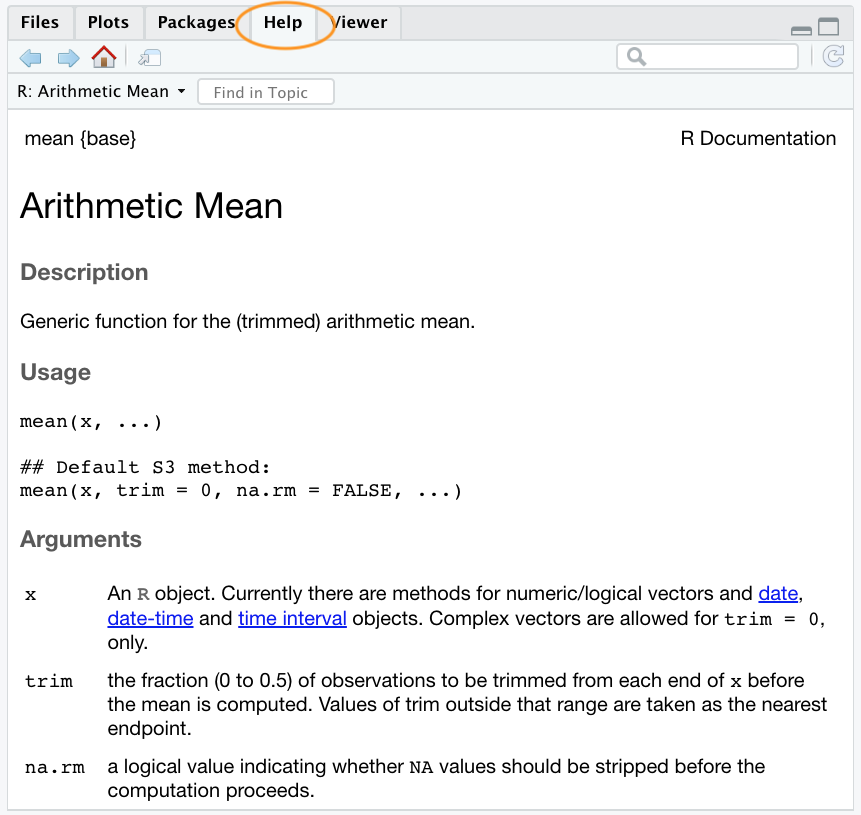

# 11 Error Messages

Errors are a normal part of programming.

Common causes include:

- misspelled object names
- missing parentheses
- missing packages
- incorrect data types

Learning to read error messages carefully is an essential R skill.

Example:

```r
mean(c(1, 2, "3"))
```

# 12 Updating Packages

## 12.1 Why Update?

Updating software helps:

- fix bugs
- improve performance
- add new features
- improve package compatibility

## 12.2 Update Packages

```r
update.packages(ask = FALSE)
```

Install an individual package:

```r
install.packages("package_name")
```

# 13 Atomic Data Types

## 13.1 Common Data Types

| Type | Example | Typical Use |
| --- | --- | --- |
| double | `34.2` | BMI, blood pressure |
| integer | `15L` | IDs, counts |
| character | `"placebo"` | Labels, groups |
| logical | `TRUE` | Conditions |

> Integers and doubles are both numeric types.

```r
# Double
bmi <- 24.8
class(bmi)

# Integer
id <- 3L
class(id)

# Character
treatment_arm <- "placebo"
class(treatment_arm)

# Logical
has_hypertension <- FALSE
class(has_hypertension)
```

# 14 Why Data Types Matter

Functions behave differently depending on data type.

```r
num1 <- 5
num1 + 2

num2 <- "5"
num2 + 2
```

# 15 Vectors

Vectors store multiple values of the same type.

```r
v1 <- c(1:5)

v2 <- c("cat", "house", "bunny")

v3 <- c(v1, v2)
v3
```

# 16 Factors

Factors are used for categorical variables.

```r
bloodtype_factor <- factor(c("A", "B", "AB", "O"))

height_factor <- factor(
  c("short", "medium", "tall"),
  ordered = TRUE,
  levels = c("short", "medium", "tall")
)
```

# 17 Lists

Lists can store mixed data types.

```r
my_list <- list(
  name = "Bill",
  age = 35,
  scores = c(92, 87, 95)
)

my_list
```

# 18 Data Frames vs Tibbles

## 18.1 Data Frames

- Base R structure
- Allows partial matching
- May automatically convert types

## 18.2 Tibbles

- Part of the tidyverse
- Cleaner printing
- Requires exact column names
- Safer behavior

```r
library(tibble)

tb <- tibble(
  age = c(25, 30, 45),
  average_height = c(55, 62, 50)
)

tb
```

# 19 GitHub and CRAN

| Source | Purpose | Install Method |
| --- | --- | --- |
| CRAN | Stable releases | `install.packages()` |
| GitHub | Development versions | `devtools::install_github()` |

## 19.1 Install from CRAN

```r
install.packages("ggplot2")
```

## 19.2 Install from GitHub

```r
install.packages("devtools")

devtools::install_github("bhelsel/RLAB")
```

# 20 Forking vs Cloning

| Forking | Cloning |
| --- | --- |
| Copies repo to GitHub account | Copies repo locally |
| Used for contributing | Used for working locally |

> Typically you fork first, then clone your fork.

# 21 Reproducible Research

One major goal of R programming is reproducibility.

A reproducible project allows someone else to:

- run the same code
- obtain the same results
- understand the workflow

Good practices include:

- using projects
- organizing files
- saving scripts
- commenting code

# 22 What is Quarto?

Quarto combines:

- code
- text
- figures
- results

into a single document.

Quarto can create:

- HTML pages
- PDFs
- presentations
- websites

This document was created using Quarto.

# 23 Free Learning

**Cheat Sheets**

[figure not shown]

[figure not shown]

[figure not shown]

[figure not shown]

- https://r4ds.hadley.nz/
- https://www.youtube.com/@RProgramming101
- https://www.youtube.com/@EquitableEquations
- https://data-flair.training/blogs/r-tutorials-home/
- https://www.coursera.org/learn/r-programming